# Daily Excercise 11 & 12

Author

Madi Schartz

Published

March 11, 2025

### Loading in necessary packages

```r
library(readr)
library(dplyr)
library(tidyr)
library(ggplot2)
library(broom)
library(purrr)
library(visdat)
library(ggpubr)
library(recipes)
```

## Part 1: Normality Testing

### Question 1 : Load the airquality dataset in R. What does this dataset represent?

###### Answer : This data represents the daily air quality measurements in New York from May to September in 1973. This data frame consists of 153 observations throughout the six variables of Ozone (ppb), Solar R (lang), Wind (mph), Temperature (degrees F), Month (1-12), and Day (1-31).

```r
?airquality
```

```
starting httpd help server ... done
```

```r
str(airquality)
```

```
'data.frame':   153 obs. of  6 variables:
 $ Ozone  : int  41 36 12 18 NA 28 23 19 8 NA ...
 $ Solar.R: int  190 118 149 313 NA NA 299 99 19 194 ...
 $ Wind   : num  7.4 8 12.6 11.5 14.3 14.9 8.6 13.8 20.1 8.6 ...
 $ Temp   : int  67 72 74 62 56 66 65 59 61 69 ...
 $ Month  : int  5 5 5 5 5 5 5 5 5 5 ...
 $ Day    : int  1 2 3 4 5 6 7 8 9 10 ...
```

```r
summary(airquality)
```

```
     Ozone           Solar.R           Wind             Temp
 Min.   :  1.00   Min.   :  7.0   Min.   : 1.700   Min.   :56.00
 1st Qu.: 18.00   1st Qu.:115.8   1st Qu.: 7.400   1st Qu.:72.00
 Median : 31.50   Median :205.0   Median : 9.700   Median :79.00
 Mean   : 42.13   Mean   :185.9   Mean   : 9.958   Mean   :77.88
 3rd Qu.: 63.25   3rd Qu.:258.8   3rd Qu.:11.500   3rd Qu.:85.00
 Max.   :168.00   Max.   :334.0   Max.   :20.700   Max.   :97.00
 NA's   :37       NA's   :7
     Month            Day
 Min.   :5.000   Min.   : 1.0
 1st Qu.:6.000   1st Qu.: 8.0
 Median :7.000   Median :16.0
 Mean   :6.993   Mean   :15.8
 3rd Qu.:8.000   3rd Qu.:23.0
 Max.   :9.000   Max.   :31.0
```

### Question 2 : Perform a Shapiro-Wilk normality test on the following variables: Ozone, Temp, Solar.R, and Wind.

```r
airquality <- na.omit(airquality)

shapiro.test(airquality$Ozone)
```

```
    Shapiro-Wilk normality test

data:  airquality$Ozone
W = 0.87355, p-value = 2.846e-08
```

```r
shapiro.test(airquality$Temp)
```

```
    Shapiro-Wilk normality test

data:  airquality$Temp
W = 0.98007, p-value = 0.09569
```

```r
shapiro.test(airquality$Solar.R)
```

```
    Shapiro-Wilk normality test

data:  airquality$Solar.R
W = 0.93285, p-value = 2.957e-05
```

```r
shapiro.test(airquality$Wind)
```

```
    Shapiro-Wilk normality test

data:  airquality$Wind
W = 0.98076, p-value = 0.1099
```

## Part 2 : Data Transformation and Feature Engineering

### Question 6 : Create a new column with case_when tranlating the Months into four seasons (Winter (Nov, Dec, Jan), Spring (Feb, Mar, Apr), Summer (May, Jun, Jul), and Fall (Aug, Sep, Oct)).

```r
airquality <- airquality |>
  mutate(Season = case_when(
    Month %in% c(11, 12, 1) ~ "Winter",
    Month %in% c(2, 3, 4) ~ "Spring",
    Month %in% c(5, 6, 7) ~ "Summer",
    Month %in% c(8, 9, 10) ~ "Fall"))
```

### Question 7 : Use table to figure out how many observations we have from each season.

###### Answer : There are 52 observations that fall in the season Fall and 59 observations that fall in the Summer season.

```r
table(airquality$Season)
```

```
  Fall Summer
    52     59
```

## Part 3 : Data Preprocessing

### Question 8 : Normalize the predictor variables (Temp, Solar.R, Wind, and Season) using a recipe

```r
# Creating the recipe:
recipe <- recipe(Ozone ~ Temp + Solar.R + Wind + Season, data = airquality) %>%
  step_center(all_numeric()) %>%
  step_scale(all_numeric())
```

### Question 9 : What is the purpose of normalizing data?

###### Answer : The purpose in normalizing data is so that we are able to fairly compare variables and interpret their relationships correctly, if the data is skewed then we aren’t able to compare justly.

### Question 10 : What function can be used to impute missing values with the mean?

###### Answer : step_impute_mean() is a function that can likely replace missing values with the mean of the column.

### Question 11 : prep and bake the data to generate a processed dataset.

```r
prep_recipe <- prep(recipe, training = airquality)
normalized_data <- bake(prep_recipe, new_data = NULL)
```

### Question 12 : Why is it necessary to both prep() and bake() the recipe?

###### Answer : It’s necessary to both prep and bake the recipe since prepping it estimates the parameters for the transformations and baking it applies those transformations to the dataset. This deals with mean, standard deviations, etc which is needed for scaling purposes.

## Part 4 :Building a Linear Regression Model

### Question 13 : Fit a linear model using Ozone as the response variable and all other variables as predictors. Remeber that the . notation can we used to include all variables.

```r
model <- lm(Ozone ~ ., data = airquality)
```

### Question 14 : Interpret the model summary output (coefficients, R-squared, p-values) in plain language

###### Answer : The model summary output gave us the relationship of Ozone levels based on the other variables.

The residuals gave us the understanding of how far off the models predictions are and since it’s showing a large range with the minimum being -37.129 to the maximum being 91.802 which suggests large errors.

The coefficients show the relationship of our response variable (Ozone) with the predictor variables of Solar, Wind, Temperature, Month, Day, and Season. It shows the intercept values which tells us that for every unit of the predictor variables, the ozone will decrease/increase whatever value is listed.

Overall, this model shows around 63% of variation (R squared value) in Ozone levels and is statistically significant with its p-value of < 2.2e-16. This means that the relationship between Ozone levels and its predictor variables are most likely true instead of coincidental.

```r
summary(model)
```

```
Call:
lm(formula = Ozone ~ ., data = airquality)

Residuals:
    Min      1Q  Median      3Q     Max
-37.129 -12.882  -3.606   8.928  91.802

Coefficients:
              Estimate Std. Error t value Pr(>|t|)
(Intercept)  -40.56185   28.85890  -1.406   0.1628
Solar.R        0.05256    0.02337   2.249   0.0266 *
Wind          -3.30244    0.64175  -5.146 1.26e-06 ***
Temp           1.98790    0.28059   7.085 1.71e-10 ***
Month         -6.54954    2.93702  -2.230   0.0279 *
Day            0.27418    0.22865   1.199   0.2332
SeasonSummer -11.25275    8.08331  -1.392   0.1669
---
Signif. codes:  0 '***' 0.001 '**' 0.01 '*' 0.05 '.' 0.1 ' ' 1

Residual standard error: 20.77 on 104 degrees of freedom
Multiple R-squared:  0.6318,    Adjusted R-squared:  0.6106
F-statistic: 29.74 on 6 and 104 DF,  p-value: < 2.2e-16
```

## Part 5 :Building a Linear Regression Mode

### Question 15 : Use broom::augment to suppliment the normalized data.frame with the fitted values and residuals

```r
augmented_data <- augment(model, normalized_data)
```

### Question 16 : Extract the residuals and visualize their distribution as a histogram and qqplot.

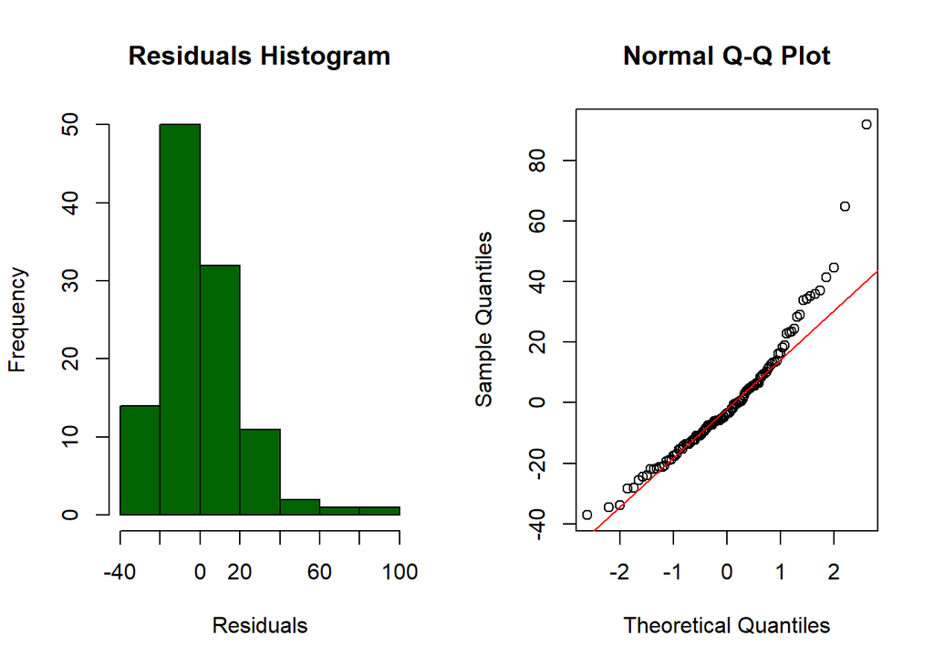

```r
residuals <- augmented_data |>
  select(.resid)

# Plot histogram and qqplot
par(mfrow = c(1, 2))  # Arrange plots side by side

# Histogram
residuals <- as.numeric(augmented_data$.resid)

hist(residuals, main = "Residuals Histogram", xlab = "Residuals", col = "darkgreen")

# QQ plot
qqnorm(residuals)
qqline(residuals, col = "red")
```

### Question 17 : Use ggarange to plot this as one image and interpret what you see in them.

###### Answer : The histogram created by the ggarange shows the residual values to be mostly normally distributed with a few outliers to the right making it look a little skewed. The bulk of residual values lays around 0 with a range of -50 to 50 with a couple around 70 and 90. The QQplot of residuals show the same story with majority of values staying with the line but as X gets larger the values slightly start to deviate from the line.

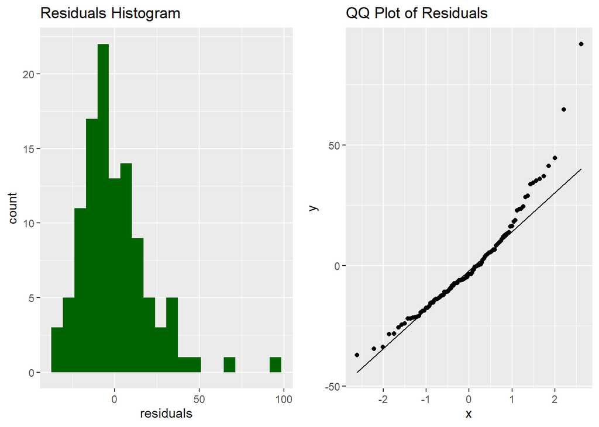

```r
hist_plot <- ggplot(data.frame(residuals), aes(x = residuals)) +
  geom_histogram(fill = "darkgreen", bins = 20) +
  labs(title = "Residuals Histogram")

qq_plot <- ggplot(data.frame(residuals), aes(sample = residuals)) +
  geom_qq() +
  geom_qq_line() +
  labs(title = "QQ Plot of Residuals")

ggarrange(hist_plot, qq_plot, ncol = 2, nrow = 1)
```

### Question 18 : Create a scatter plot of actual vs. predicted values using ggpubr with the following setting:

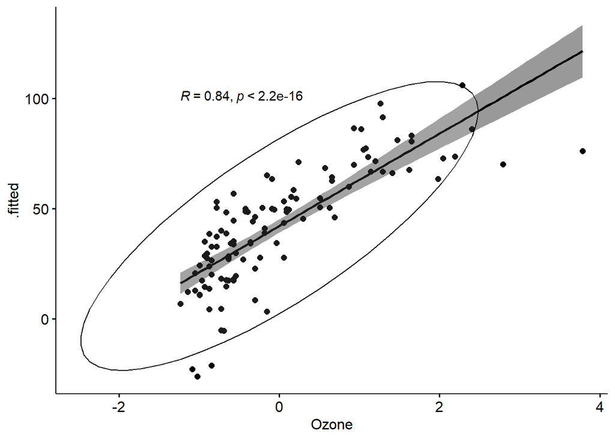

```r
ggscatter(augmented_data, x = "Ozone", y = ".fitted",
          add = "reg.line", conf.int = TRUE,
          cor.coef = TRUE, cor.method = "spearman",
          ellipse = TRUE)
```